# Communicate Data Finding : Prosper Loan Data

# What the Project will test

- Introduction of the topic and dataset
- Dataset Investigation and preliminary wrangling
- Further Data Wrangling
- Univariate Exploration and Analysis
- Bivariate Exploration and Analysis
- Multivariate Exploration and Analysis
- Conclusions and answers

## Dataset

> - Loan Data from Prosper: This data set contains 113,937 loans with 81 variables on each loan, including loan amount, borrower rate (or interest rate), current loan status, borrower income, and many others
> - The source data (Prosper Loan Data) was from Udacity website.

### Features :

The Features included in the Data are as follows :

- **ListingKey**: Unique key for each listing, same value as the 'key' used in the listing object in the API.
- **ListingNumber**: The number that uniquely identifies the listing to the public as displayed on the website.
- **ListingCreationDate**:The date the listing was created.
- **CreditGrade**:The Credit rating that was assigned at the time the listing went live. Applicable for listings pre-2009 period and will only be populated for those listings.
- **Term**:The length of the loan expressed in months.
- **LoanStatus**:The current status of the loan: Cancelled, Chargedoff, Completed, Current, Defaulted, FinalPaymentInProgress, PastDue. The PastDue status will be accompanied by a delinquency bucket.
- **ClosedDate**:Closed date is applicable for Cancelled, Completed, Chargedoff and Defaulted loan statuses.
- **BorrowerAPR**:The Borrower's Annual Percentage Rate (APR) for the loan.
- **BorrowerRate**:The Borrower's interest rate for this loan.
- **LenderYield**:The Lender yield on the loan. Lender yield is equal to the interest rate on the loan less the servicing fee.
- **EstimatedEffectiveYield**:Effective yield is equal to the borrower interest rate (i) minus the servicing fee rate, (ii) minus estimated uncollected interest on charge-offs, (iii) plus estimated collected late fees. Applicable for loans originated after July 2009.
- **EstimatedLoss**:Estimated loss is the estimated principal loss on charge-offs. Applicable for loans originated after July 2009.
- **EstimatedReturn**:The estimated return assigned to the listing at the time it was created. Estimated return is the difference between the Estimated Effective Yield and the Estimated Loss Rate. Applicable for loans originated after July 2009.
- **ProsperRating** :The Prosper Rating assigned at the time the listing was created: 0 - N/A, 1 - HR, 2 - E, 3 - D, 4 - C, 5 - B, 6 - A, 7 - AA. Applicable for loans originated after July 2009.
- **ProsperRating (Alpha)**:The Prosper Rating assigned at the time the listing was created between AA - HR. Applicable for loans originated after July 2009.
- **ProsperScore**:A custom risk score built using historical Prosper data. The score ranges from 1-10, with 10 being the best, or lowest risk score. Applicable for loans originated after July 2009.
- **ListingCategory**:The category of the listing that the borrower selected when posting their listing: 0 - Not Available, 1 - Debt Consolidation, 2 - Home Improvement, 3 - Business, 4 - Personal Loan, 5 - Student Use, 6 - Auto, 7- Other, 8 - Baby&Adoption, 9 - Boat, 10 - Cosmetic Procedure, 11 - Engagement Ring, 12 - Green Loans, 13 - Household Expenses, 14 - Large Purchases, 15 - Medical/Dental, 16 - Motorcycle, 17 - RV, 18 - Taxes, 19 - Vacation, 20 - Wedding Loans
- **BorrowerState**:The two letter abbreviation of the state of the address of the borrower at the time the Listing was created.
- **Occupation**:The Occupation selected by the Borrower at the time they created the listing.
- **EmploymentStatus**:The employment status of the borrower at the time they posted the listing.
- **EmploymentStatusDuration**:The length in months of the employment status at the time the listing was created.
- **IsBorrowerHomeowner**:A Borrower will be classified as a homowner if they have a mortgage on their credit profile or provide documentation confirming they are a homeowner.
- **CurrentlyInGroup**:Specifies whether or not the Borrower was in a group at the time the listing was created.
- **GroupKey**:The Key of the group in which the Borrower is a member of. Value will be null if the borrower does not have a group affiliation.
- **DateCreditPulled**:The date the credit profile was pulled.
- **CreditScoreRangeLower**:The lower value representing the range of the borrower's credit score as provided by a consumer credit rating agency.
- **CreditScoreRangeUpper**:The upper value representing the range of the borrower's credit score as provided by a consumer credit rating agency.
- **FirstRecordedCreditLine**:The date the first credit line was opened.
- **CurrentCreditLines**:Number of current credit lines at the time the credit profile was pulled.
- **OpenCreditLines**:Number of open credit lines at the time the credit profile was pulled.
- **TotalCreditLinespast7years**:Number of credit lines in the past seven years at the time the credit profile was pulled.
- **OpenRevolvingAccounts**:Number of open revolving accounts at the time the credit profile was pulled.
- **OpenRevolvingMonthlyPayment**:Monthly payment on revolving accounts at the time the credit profile was pulled.
- **InquiriesLast6Months**:Number of inquiries in the past six months at the time the credit profile was pulled.
- **TotalInquiries**:Total number of inquiries at the time the credit profile was pulled.
- **CurrentDelinquencies**:Number of accounts delinquent at the time the credit profile was pulled.
- **AmountDelinquent**:Dollars delinquent at the time the credit profile was pulled.
- **DelinquenciesLast7Years**:Number of delinquencies in the past 7 years at the time the credit profile was pulled.
- **PublicRecordsLast10Years**:Number of public records in the past 10 years at the time the credit profile was pulled.
- **PublicRecordsLast12Months**:Number of public records in the past 12 months at the time the credit profile was pulled.
- **RevolvingCreditBalance**:Dollars of revolving credit at the time the credit profile was pulled.
- **BankcardUtilization**:The percentage of available revolving credit that is utilized at the time the credit profile was pulled.
- **AvailableBankcardCredit**:The total available credit via bank card at the time the credit profile was pulled.
- **TotalTrades**:Number of trade lines ever opened at the time the credit profile was pulled.
- **TradesNeverDelinquent**:Number of trades that have never been delinquent at the time the credit profile was pulled.
- **TradesOpenedLast6Months**:Number of trades opened in the last 6 months at the time the credit profile was pulled.
- **DebtToIncomeRatio**:The debt to income ratio of the borrower at the time the credit profile was pulled. This value is Null if the debt to income ratio is not available. This value is capped at 10.01 (any debt to income ratio larger than 1000% will be returned as 1001%).
- **IncomeRange**:The income range of the borrower at the time the listing was created.
- **IncomeVerifiable**:The borrower indicated they have the required documentation to support their income.
- **StatedMonthlyIncome**:The monthly income the borrower stated at the time the listing was created.
- **LoanKey**:Unique key for each loan. This is the same key that is used in the API.
- **TotalProsperLoans** Number of Prosper loans the borrower at the time they created this listing. This value will be null if the borrower had no prior loans.
- **TotalProsperPaymentsBilled**:Number of on time payments the borrower made on Prosper loans at the time they created this listing. This value will be null if the borrower had no prior loans.
- **OnTimeProsperPayments**:Number of on time payments the borrower had made on Prosper loans at the time they created this listing. This value will be null if the borrower has no prior loans.
- **ProsperPaymentsLessThanOneMonthLate**:Number of payments the borrower made on Prosper loans that were less than one month late at the time they created this listing. This value will be null if the borrower had no prior loans.
- **ProsperPaymentsOneMonthPlusLate**:Number of payments the borrower made on Prosper loans that were greater than one month late at the time they created this listing. This value will be null if the borrower had no prior loans.
- **ProsperPrincipalBorrowed**:Total principal borrowed on Prosper loans at the time the listing was created. This value will be null if the borrower had no prior loans.
- **ProsperPrincipalOutstanding**:Principal outstanding on Prosper loans at the time the listing was created. This value will be null if the borrower had no prior loans.
- **ScorexChangeAtTimeOfListing**:Borrower's credit score change at the time the credit profile was pulled. This will be the change relative to the borrower's last Prosper loan. This value will be null if the borrower had no prior loans.
- **LoanCurrentDaysDelinquent**:The number of days delinquent.
- **LoanFirstDefaultedCycleNumber**:The cycle the loan was charged off. If the loan has not charged off the value will be null.
- **LoanMonthsSinceOrigination**:Number of months since the loan originated.
- **LoanNumber**:Unique numeric value associated with the loan.
- **LoanOriginalAmount**:The origination amount of the loan.
- **LoanOriginationDate**:The date the loan was originated.
- **LoanOriginationQuarter**:The quarter in which the loan was originated.
- **MemberKey**:The unique key that is associated with the borrower. This is the same identifier that is used in the API member object.
- **MonthlyLoanPayment**:The scheduled monthly loan payment.
- **LP_CustomerPayments**:Pre charge-off cumulative gross payments made by the borrower on the loan. If the loan has charged off, this value will exclude any recoveries.
- **LP_CustomerPrincipalPayments**:Pre charge-off cumulative principal payments made by the borrower on the loan. If the loan has charged off, this value will exclude any recoveries.
- **LP_InterestandFees**:Pre charge-off cumulative interest and fees paid by the borrower. If the loan has charged off, this value will exclude any recoveries.
- **LP_ServiceFees**:Cumulative service fees paid by the investors who have invested in the loan.
- **LP_CollectionFees**:Cumulative collection fees paid by the investors who have invested in the loan.
- **LP_GrossPrincipalLoss**:The gross charged off amount of the loan.
- **LP_NetPrincipalLoss**:The principal that remains uncollected after any recoveries.
- **LP_NonPrincipalRecoverypayments**:The interest and fee component of any recovery payments. The current payment policy applies payments in the following order: Fees, interest, principal.
- **PercentFunded**:Percent the listing was funded.
- **Recommendations**:Number of recommendations the borrower had at the time the listing was created.
- I**nvestmentFromFriendsCount**:Number of friends that made an investment in the loan.
- **InvestmentFromFriendsAmount**:Dollar amount of investments that were made by friends.
- **Investors**:The number of investors that funded the loan.

### Questions to be answered:

1. What is the primary justification for loan applications?
2. Do borrowers take on more debt than they can reasonably pay off?
3. What is the number of prosper score rating for every loan?
4. What is the current loan status for most loans?
5. Which occupation gets highest loan amount on an average?
6. Which occupation has the largest number of borrower?
7. How does loan amount differ with respect to the income range?

```python
import pandas as pd
import numpy as np
import seaborn as sb
import matplotlib.pyplot as plt
%matplotlib inline
```

# Loading the dataset and having a visual of it.

```python
orignal_prosperLoanData = pd.read_csv(r'prosperLoanData.csv')
# the datasets is per loan borrower
```

### The Table Below shows a visual of the first 5 Rows in the dataset

```python
orignal_prosperLoanData.head(5)
```

|  | ListingKey | ListingNumber | ListingCreationDate | CreditGrade | Term | LoanStatus | ClosedDate | BorrowerAPR | BorrowerRate | LenderYield | ... | LP_ServiceFees | LP_CollectionFees | LP_GrossPrincipalLoss | LP_NetPrincipalLoss | LP_NonPrincipalRecoverypayments | PercentFunded | Recommendations | InvestmentFromFriendsCount | InvestmentFromFriendsAmount | Investors |
| --- | --- | --- | --- | --- | --- | --- | --- | --- | --- | --- | --- | --- | --- | --- | --- | --- | --- | --- | --- | --- | --- |
| 0 | 1021339766868145413AB3B | 193129 | 2007-08-26 19:09:29.263000000 | C | 36 | Completed | 2009-08-14 00:00:00 | 0.16516 | 0.1580 | 0.1380 | ... | -133.18 | 0.0 | 0.0 | 0.0 | 0.0 | 1.0 | 0 | 0 | 0.0 | 258 |
| 1 | 10273602499503308B223C1 | 1209647 | 2014-02-27 08:28:07.900000000 | NaN | 36 | Current | NaN | 0.12016 | 0.0920 | 0.0820 | ... | 0.00 | 0.0 | 0.0 | 0.0 | 0.0 | 1.0 | 0 | 0 | 0.0 | 1 |
| 2 | 0EE9337825851032864889A | 81716 | 2007-01-05 15:00:47.090000000 | HR | 36 | Completed | 2009-12-17 00:00:00 | 0.28269 | 0.2750 | 0.2400 | ... | -24.20 | 0.0 | 0.0 | 0.0 | 0.0 | 1.0 | 0 | 0 | 0.0 | 41 |
| 3 | 0EF5356002482715299901A | 658116 | 2012-10-22 11:02:35.010000000 | NaN | 36 | Current | NaN | 0.12528 | 0.0974 | 0.0874 | ... | -108.01 | 0.0 | 0.0 | 0.0 | 0.0 | 1.0 | 0 | 0 | 0.0 | 158 |
| 4 | 0F023589499656230C5E3E2 | 909464 | 2013-09-14 18:38:39.097000000 | NaN | 36 | Current | NaN | 0.24614 | 0.2085 | 0.1985 | ... | -60.27 | 0.0 | 0.0 | 0.0 | 0.0 | 1.0 | 0 | 0 | 0.0 | 20 |

5 rows × 81 columns

```python
##  Using shape to get the number of rows and columns of the dataframe
orignal_prosperLoanData.shape
```

```
(113937, 81)
```

> From observation we can see that the dataframe contains 113,937 rows and 81 columns

#### Since we have a large dataset, we will only select the columns that we will be interested to use

```python
# checking all the columns to see the ones we will need in your analysis
orignal_prosperLoanData.columns
```

```
Index(['ListingKey', 'ListingNumber', 'ListingCreationDate', 'CreditGrade',
       'Term', 'LoanStatus', 'ClosedDate', 'BorrowerAPR', 'BorrowerRate',
       'LenderYield', 'EstimatedEffectiveYield', 'EstimatedLoss',
       'EstimatedReturn', 'ProsperRating (numeric)', 'ProsperRating (Alpha)',
       'ProsperScore', 'ListingCategory (numeric)', 'BorrowerState',
       'Occupation', 'EmploymentStatus', 'EmploymentStatusDuration',
       'IsBorrowerHomeowner', 'CurrentlyInGroup', 'GroupKey',
       'DateCreditPulled', 'CreditScoreRangeLower', 'CreditScoreRangeUpper',
       'FirstRecordedCreditLine', 'CurrentCreditLines', 'OpenCreditLines',
       'TotalCreditLinespast7years', 'OpenRevolvingAccounts',
       'OpenRevolvingMonthlyPayment', 'InquiriesLast6Months', 'TotalInquiries',
       'CurrentDelinquencies', 'AmountDelinquent', 'DelinquenciesLast7Years',
       'PublicRecordsLast10Years', 'PublicRecordsLast12Months',
       'RevolvingCreditBalance', 'BankcardUtilization',
       'AvailableBankcardCredit', 'TotalTrades',
       'TradesNeverDelinquent (percentage)', 'TradesOpenedLast6Months',
       'DebtToIncomeRatio', 'IncomeRange', 'IncomeVerifiable',
       'StatedMonthlyIncome', 'LoanKey', 'TotalProsperLoans',
       'TotalProsperPaymentsBilled', 'OnTimeProsperPayments',
       'ProsperPaymentsLessThanOneMonthLate',
       'ProsperPaymentsOneMonthPlusLate', 'ProsperPrincipalBorrowed',
       'ProsperPrincipalOutstanding', 'ScorexChangeAtTimeOfListing',
       'LoanCurrentDaysDelinquent', 'LoanFirstDefaultedCycleNumber',
       'LoanMonthsSinceOrigination', 'LoanNumber', 'LoanOriginalAmount',
       'LoanOriginationDate', 'LoanOriginationQuarter', 'MemberKey',
       'MonthlyLoanPayment', 'LP_CustomerPayments',
       'LP_CustomerPrincipalPayments', 'LP_InterestandFees', 'LP_ServiceFees',
       'LP_CollectionFees', 'LP_GrossPrincipalLoss', 'LP_NetPrincipalLoss',
       'LP_NonPrincipalRecoverypayments', 'PercentFunded', 'Recommendations',
       'InvestmentFromFriendsCount', 'InvestmentFromFriendsAmount',
       'Investors'],
      dtype='object')
```

```python
orignal_prosperLoanData.info()
```

```
<class 'pandas.core.frame.DataFrame'>
RangeIndex: 113937 entries, 0 to 113936
Data columns (total 81 columns):
 #   Column                               Non-Null Count   Dtype
---  ------                               --------------   -----
 0   ListingKey                           113937 non-null  object
 1   ListingNumber                        113937 non-null  int64
 2   ListingCreationDate                  113937 non-null  object
 3   CreditGrade                          28953 non-null   object
 4   Term                                 113937 non-null  int64
 5   LoanStatus                           113937 non-null  object
 6   ClosedDate                           55089 non-null   object
 7   BorrowerAPR                          113912 non-null  float64
 8   BorrowerRate                         113937 non-null  float64
 9   LenderYield                          113937 non-null  float64
```

[output cut: 73 more lines]

### Since we have a very large dataset, we will only work with columns of interest

#### Extracting the desired columns from the dataframe

```python
# Extract the desired columns from the dataframe
extracted_columns = ["LoanStatus","LenderYield","ProsperRating (numeric)","ProsperScore","BorrowerAPR","BorrowerRate","ListingCategory (numeric)","DebtToIncomeRatio","EstimatedEffectiveYield","Occupation","EmploymentStatus","IsBorrowerHomeowner",
               "CurrentDelinquencies","AmountDelinquent","DelinquenciesLast7Years","IncomeRange","TotalProsperLoans","LoanOriginalAmount","OnTimeProsperPayments","BorrowerState","Investors"]
```

```python
data_prosperLoan = orignal_prosperLoanData[extracted_columns]
```

```python
data_prosperLoan.head(5)
```

|  | LoanStatus | LenderYield | ProsperRating (numeric) | ProsperScore | BorrowerAPR | BorrowerRate | ListingCategory (numeric) | DebtToIncomeRatio | EstimatedEffectiveYield | Occupation | ... | IsBorrowerHomeowner | CurrentDelinquencies | AmountDelinquent | DelinquenciesLast7Years | IncomeRange | TotalProsperLoans | LoanOriginalAmount | OnTimeProsperPayments | BorrowerState | Investors |
| --- | --- | --- | --- | --- | --- | --- | --- | --- | --- | --- | --- | --- | --- | --- | --- | --- | --- | --- | --- | --- | --- |
| 0 | Completed | 0.1380 | NaN | NaN | 0.16516 | 0.1580 | 0 | 0.17 | NaN | Other | ... | True | 2.0 | 472.0 | 4.0 | $25,000-49,999 | NaN | 9425 | NaN | CO | 258 |
| 1 | Current | 0.0820 | 6.0 | 7.0 | 0.12016 | 0.0920 | 2 | 0.18 | 0.07960 | Professional | ... | False | 0.0 | 0.0 | 0.0 | $50,000-74,999 | NaN | 10000 | NaN | CO | 1 |
| 2 | Completed | 0.2400 | NaN | NaN | 0.28269 | 0.2750 | 0 | 0.06 | NaN | Other | ... | False | 1.0 | NaN | 0.0 | Not displayed | NaN | 3001 | NaN | GA | 41 |
| 3 | Current | 0.0874 | 6.0 | 9.0 | 0.12528 | 0.0974 | 16 | 0.15 | 0.08490 | Skilled Labor | ... | True | 4.0 | 10056.0 | 14.0 | $25,000-49,999 | NaN | 10000 | NaN | GA | 158 |
| 4 | Current | 0.1985 | 3.0 | 4.0 | 0.24614 | 0.2085 | 2 | 0.26 | 0.18316 | Executive | ... | True | 0.0 | 0.0 | 0.0 | $100,000+ | 1.0 | 15000 | 11.0 | MN | 20 |

5 rows × 21 columns

```python
data_prosperLoan.sample(5)
```

|  | LoanStatus | LenderYield | ProsperRating (numeric) | ProsperScore | BorrowerAPR | BorrowerRate | ListingCategory (numeric) | DebtToIncomeRatio | EstimatedEffectiveYield | Occupation | ... | IsBorrowerHomeowner | CurrentDelinquencies | AmountDelinquent | DelinquenciesLast7Years | IncomeRange | TotalProsperLoans | LoanOriginalAmount | OnTimeProsperPayments | BorrowerState | Investors |
| --- | --- | --- | --- | --- | --- | --- | --- | --- | --- | --- | --- | --- | --- | --- | --- | --- | --- | --- | --- | --- | --- |
| 741 | Current | 0.1840 | 4.0 | 4.0 | 0.21832 | 0.1940 | 1 | 0.25 | 0.17019 | Other | ... | False | 0.0 | 0.0 | 0.0 | $50,000-74,999 | NaN | 14000 | NaN | FL | 1 |
| 41 | Current | 0.1985 | 5.0 | 8.0 | 0.23318 | 0.2085 | 7 | 0.08 | 0.19500 | Other | ... | True | 0.0 | 0.0 | 1.0 | $100,000+ | NaN | 13000 | NaN | MI | 181 |
| 108558 | Current | 0.1870 | 4.0 | 4.0 | 0.23438 | 0.1970 | 3 | NaN | 0.17274 | Other | ... | False | 0.0 | 0.0 | 2.0 | $1-24,999 | NaN | 3000 | NaN | MN | 1 |
| 108184 | Current | 0.1625 | 4.0 | 7.0 | 0.20933 | 0.1725 | 1 | 0.53 | 0.15163 | Other | ... | True | 0.0 | 0.0 | 0.0 | $25,000-49,999 | NaN | 10000 | NaN | NE | 1 |
| 62837 | Current | 0.1775 | 4.0 | 2.0 | 0.22505 | 0.1875 | 14 | 0.50 | 0.16463 | Medical Technician | ... | False | 0.0 | 0.0 | 0.0 | $1-24,999 | NaN | 4000 | NaN | NJ | 1 |

5 rows × 21 columns

```python
data_prosperLoan.info()
```

```
<class 'pandas.core.frame.DataFrame'>
RangeIndex: 113937 entries, 0 to 113936
Data columns (total 21 columns):
 #   Column                     Non-Null Count   Dtype
---  ------                     --------------   -----
 0   LoanStatus                 113937 non-null  object
 1   LenderYield                113937 non-null  float64
 2   ProsperRating (numeric)    84853 non-null   float64
 3   ProsperScore               84853 non-null   float64
 4   BorrowerAPR                113912 non-null  float64
 5   BorrowerRate               113937 non-null  float64
 6   ListingCategory (numeric)  113937 non-null  int64
 7   DebtToIncomeRatio          105383 non-null  float64
 8   EstimatedEffectiveYield    84853 non-null   float64
 9   Occupation                 110349 non-null  object
 10  EmploymentStatus           111682 non-null  object
 11  IsBorrowerHomeowner        113937 non-null  bool
 12  CurrentDelinquencies       113240 non-null  float64
 13  AmountDelinquent           106315 non-null  float64
 14  DelinquenciesLast7Years    112947 non-null  float64
 15  IncomeRange                113937 non-null  object
 16  TotalProsperLoans          22085 non-null   float64
 17  LoanOriginalAmount         113937 non-null  int64
 18  OnTimeProsperPayments      22085 non-null   float64
 19  BorrowerState              108422 non-null  object
 20  Investors                  113937 non-null  int64
dtypes: bool(1), float64(12), int64(3), object(5)
memory usage: 17.5+ MB
```

```python
### Changing column into suitable names
data_prosperLoan = data_prosperLoan.rename(columns={'ProsperRating (numeric)': 'ProsperRating', 'ListingCategory (numeric)':'ListingCategory'})
```

```python
data_prosperLoan.info()
```

```
<class 'pandas.core.frame.DataFrame'>
RangeIndex: 113937 entries, 0 to 113936
Data columns (total 21 columns):
 #   Column                   Non-Null Count   Dtype
---  ------                   --------------   -----
 0   LoanStatus               113937 non-null  object
 1   LenderYield              113937 non-null  float64
 2   ProsperRating            84853 non-null   float64
 3   ProsperScore             84853 non-null   float64
 4   BorrowerAPR              113912 non-null  float64
 5   BorrowerRate             113937 non-null  float64
 6   ListingCategory          113937 non-null  int64
 7   DebtToIncomeRatio        105383 non-null  float64
 8   EstimatedEffectiveYield  84853 non-null   float64
 9   Occupation               110349 non-null  object
 10  EmploymentStatus         111682 non-null  object
 11  IsBorrowerHomeowner      113937 non-null  bool
 12  CurrentDelinquencies     113240 non-null  float64
 13  AmountDelinquent         106315 non-null  float64
 14  DelinquenciesLast7Years  112947 non-null  float64
 15  IncomeRange              113937 non-null  object
 16  TotalProsperLoans        22085 non-null   float64
 17  LoanOriginalAmount       113937 non-null  int64
 18  OnTimeProsperPayments    22085 non-null   float64
 19  BorrowerState            108422 non-null  object
 20  Investors                113937 non-null  int64
dtypes: bool(1), float64(12), int64(3), object(5)
memory usage: 17.5+ MB
```

## Cleansing the dataset

```python
# The desired columns of the dataframe are 20
data_prosperLoan.shape
```

```
(113937, 21)
```

### We can check to see the sum of null values in the dataset for each column

```python
## Checking for null value
data_prosperLoan.isnull().sum()
```

```
LoanStatus                     0
LenderYield                    0
ProsperRating              29084
ProsperScore               29084
BorrowerAPR                   25
BorrowerRate                   0
ListingCategory                0
DebtToIncomeRatio           8554
EstimatedEffectiveYield    29084
Occupation                  3588
EmploymentStatus            2255
IsBorrowerHomeowner            0
CurrentDelinquencies         697
AmountDelinquent            7622
DelinquenciesLast7Years      990
IncomeRange                    0
TotalProsperLoans          91852
LoanOriginalAmount             0
OnTimeProsperPayments      91852
BorrowerState               5515
Investors                      0
dtype: int64
```

### Removing null values from the dataset

```python
prosperLoan = data_prosperLoan.copy()
```

```python
prosperLoan.dropna(inplace = True)
```

```python
prosperLoan.shape
```

```
(17698, 21)
```

```python
prosperLoan
```

|  | LoanStatus | LenderYield | ProsperRating | ProsperScore | BorrowerAPR | BorrowerRate | ListingCategory | DebtToIncomeRatio | EstimatedEffectiveYield | Occupation | ... | IsBorrowerHomeowner | CurrentDelinquencies | AmountDelinquent | DelinquenciesLast7Years | IncomeRange | TotalProsperLoans | LoanOriginalAmount | OnTimeProsperPayments | BorrowerState | Investors |
| --- | --- | --- | --- | --- | --- | --- | --- | --- | --- | --- | --- | --- | --- | --- | --- | --- | --- | --- | --- | --- | --- |
| 4 | Current | 0.1985 | 3.0 | 4.0 | 0.24614 | 0.2085 | 2 | 0.26 | 0.18316 | Executive | ... | True | 0.0 | 0.0 | 0.0 | $100,000+ | 1.0 | 15000 | 11.0 | MN | 20 |
| 16 | Current | 0.2709 | 2.0 | 4.0 | 0.30748 | 0.2809 | 6 | 0.15 | 0.24730 | Professional | ... | True | 1.0 | 2469.0 | 12.0 | $75,000-99,999 | 3.0 | 4000 | 67.0 | CA | 8 |
| 19 | Current | 0.2125 | 3.0 | 8.0 | 0.24754 | 0.2225 | 1 | 0.41 | 0.19520 | Laborer | ... | False | 0.0 | 0.0 | 0.0 | $25,000-49,999 | 1.0 | 6500 | 12.0 | OR | 1 |
| 33 | Completed | 0.0685 | 7.0 | 10.0 | 0.08191 | 0.0785 | 7 | 0.05 | 0.05550 | Other | ... | False | 0.0 | 0.0 | 0.0 | $100,000+ | 1.0 | 16000 | 8.0 | IL | 326 |
| 47 | Current | 0.1199 | 6.0 | 8.0 | 0.15833 | 0.1299 | 1 | 0.35 | 0.11480 | Professional | ... | True | 0.0 | 0.0 | 0.0 | $50,000-74,999 | 3.0 | 15000 | 20.0 | CO | 1 |
| ... | ... | ... | ... | ... | ... | ... | ... | ... | ... | ... | ... | ... | ... | ... | ... | ... | ... | ... | ... | ... | ... |
| 113924 | Current | 0.1399 | 6.0 | 8.0 | 0.17317 | 0.1499 | 13 | 0.17 | 0.13460 | Other | ... | False | 0.0 | 0.0 | 2.0 | $25,000-49,999 | 2.0 | 5000 | 35.0 | WA | 83 |
| 113928 | Completed | 0.1799 | 4.0 | 6.0 | 0.22362 | 0.1899 | 3 | 0.27 | 0.17570 | Other | ... | False | 0.0 | 0.0 | 0.0 | $25,000-49,999 | 5.0 | 2000 | 47.0 | CO | 25 |
| 113930 | Current | 0.1539 | 5.0 | 6.0 | 0.20053 | 0.1639 | 1 | 0.20 | 0.14520 | Professional | ... | True | 0.0 | 0.0 | 0.0 | $75,000-99,999 | 1.0 | 3000 | 7.0 | IN | 52 |
| 113933 | FinalPaymentInProgress | 0.1010 | 6.0 | 8.0 | 0.13220 | 0.1110 | 7 | 0.11 | 0.10070 | Professional | ... | True | 1.0 | 5062.0 | 4.0 | $75,000-99,999 | 3.0 | 2000 | 60.0 | PA | 22 |
| 113935 | Completed | 0.2505 | 4.0 | 5.0 | 0.28408 | 0.2605 | 2 | 0.48 | 0.24450 | Food Service | ... | True | 0.0 | 0.0 | 0.0 | $25,000-49,999 | 1.0 | 15000 | 16.0 | GA | 274 |

17698 rows × 21 columns

```python
prosperLoan.info()
```

```
<class 'pandas.core.frame.DataFrame'>
Int64Index: 17698 entries, 4 to 113935
Data columns (total 21 columns):
 #   Column                   Non-Null Count  Dtype
---  ------                   --------------  -----
 0   LoanStatus               17698 non-null  object
 1   LenderYield              17698 non-null  float64
 2   ProsperRating            17698 non-null  float64
 3   ProsperScore             17698 non-null  float64
 4   BorrowerAPR              17698 non-null  float64
 5   BorrowerRate             17698 non-null  float64
 6   ListingCategory          17698 non-null  int64
 7   DebtToIncomeRatio        17698 non-null  float64
 8   EstimatedEffectiveYield  17698 non-null  float64
 9   Occupation               17698 non-null  object
 10  EmploymentStatus         17698 non-null  object
 11  IsBorrowerHomeowner      17698 non-null  bool
 12  CurrentDelinquencies     17698 non-null  float64
 13  AmountDelinquent         17698 non-null  float64
 14  DelinquenciesLast7Years  17698 non-null  float64
 15  IncomeRange              17698 non-null  object
 16  TotalProsperLoans        17698 non-null  float64
 17  LoanOriginalAmount       17698 non-null  int64
 18  OnTimeProsperPayments    17698 non-null  float64
 19  BorrowerState            17698 non-null  object
 20  Investors                17698 non-null  int64
dtypes: bool(1), float64(12), int64(3), object(5)
memory usage: 2.9+ MB
```

# Univarate Visualization - Exploration

- We can explore some Numerical Univariate Data e.g distribution of TotalProsperLoan
- Numerical univariate data consists of observations that are numbers

## Primary justification for loan applications

##### We can check the category that the borrower selected when posting their listing

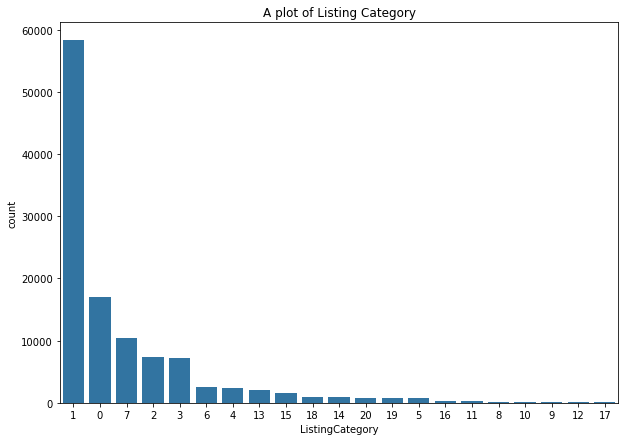

```python
plt.rcParams["figure.figsize"] = (10,7)
listing_category = data_prosperLoan["ListingCategory"].value_counts()
variable_index = listing_category.index
fav_color = sb.color_palette()[0]
sb.countplot(data = data_prosperLoan , x = "ListingCategory", order=variable_index, color= fav_color )
plt.title('A plot of Listing Category');
```

```python
# Store all the numeric categories and their titles in a dictionary
listingCategory_titles = {0 : 'Not Available', 1 : 'Debt Consolidation', 2 : 'Home Improvement', 3: 'Business',
                   4 : 'Personal Loan', 5 : 'Student Use', 6 : 'Auto', 7 : 'Other', 8 : 'Baby & Adoption',
                   9 : 'Boat', 10 : 'Cosmetic Procedure', 11 : 'Engagement Ring', 12 : 'Green Loans',
                  13 : 'Household Expenses', 14 : 'Large Purchases', 15 : 'Medical or Dental', 16 : 'Motorcycle',
                  17 : 'RV', 18 : 'Taxes', 19 : 'Vacation', 20 : 'Wedding Loans'}

# Map the dictionary contents to the ListingCategory column
prosperLoan['ListingCategory'] = prosperLoan['ListingCategory'].map(listingCategory_titles)

# Preview results
prosperLoan['ListingCategory'].unique()
```

```
array(['Home Improvement', 'Auto', 'Debt Consolidation', 'Other',
       'Vacation', 'Engagement Ring', 'Business', 'Large Purchases',
       'Taxes', 'Medical or Dental', 'Household Expenses',
       'Wedding Loans', 'Boat', 'Not Available', 'Baby & Adoption',
       'Motorcycle', 'Student Use', 'RV', 'Cosmetic Procedure',
       'Green Loans'], dtype=object)
```

```python
prosperLoan['ListingCategory'].value_counts()
```

```
Debt Consolidation    9625
Home Improvement      2303
Other                 1896
Business              1101
Auto                   812
Medical or Dental      485
Household Expenses     416
Taxes                  248
Vacation               223
Wedding Loans          168
Large Purchases        135
Student Use             84
Baby & Adoption         54
Motorcycle              50
Engagement Ring         31
Boat                    20
Green Loans             16
RV                      13
Cosmetic Procedure       9
Not Available            9
Name: ListingCategory, dtype: int64
```

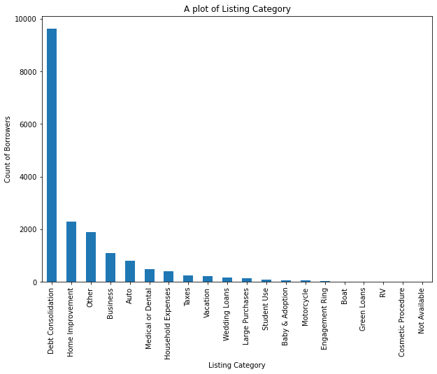

```python
prosperLoan['ListingCategory'].value_counts().plot(kind='bar')
plt.title('A plot of Listing Category')
plt.xlabel('Listing Category')
plt.ylabel('Count of Borrowers');
```

> We can see from the graph above that the majority of borrowers seek loans to pay off their current debt or consolidate new debt. This proportion is significantly higher than individuals who apply for loans for common causes including home remodeling, business, car-related expenses, and medical needs. The most money is typically borrowed for debt consolidation.

> Aside from financing their businesses and house related expenses, people appear to rely on loans to pay for their weddings, pay taxes, using the loans to fund for vaccation, child adaption, making large purchases, and student use.

## Do borrowers take on more debt than they can reasonably pay off?

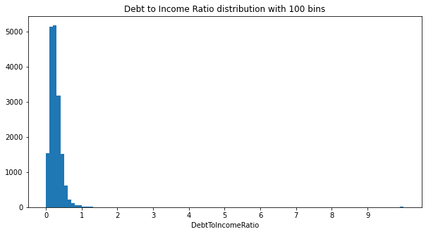

```python
###  histogram distribution for Debt to Income Ratio
bins = np.linspace(0, prosperLoan.DebtToIncomeRatio.max(), 100)

plt.figure(figsize=(10, 5))
plt.hist(data=prosperLoan, x='DebtToIncomeRatio', bins=bins, color = fav_color);
plt.xticks(np.arange(0, 10, 1))
plt.title('Debt to Income Ratio distribution with 100 bins')
plt.xlabel('DebtToIncomeRatio');
```

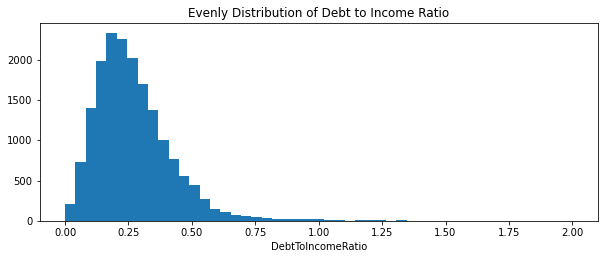

```python
plt.figure(figsize=(10, 8))
bins = np.linspace(0, 2, 50)
plt.subplot(2,1,2)
plt.hist(data=prosperLoan, x='DebtToIncomeRatio', bins=bins, color = fav_color)
plt.title('Evenly Distribution of Debt to Income Ratio')
plt.xlabel('DebtToIncomeRatio');
```

> Right-skewed distribution can be seen in the debt-to-income ratio. Most borrowers appear to choose taking out loans that are affordable. This is understandable because the majority of numbers are spread out between 0 and 1.

## Lets check the number of prosper score rating for every loans in the dataset

#### ProsperScore is a custom risk score built using historical Prosper data. The score ranges from 1-10, with 10 being the best, or lowest risk score.

```python
prosperScore_count = prosperLoan["ProsperScore"].value_counts()
prosperScore_count
```

```
8.0     2696
6.0     2158
7.0     1981
5.0     1863
9.0     1759
4.0     1714
10.0    1611
3.0     1306
2.0     1234
11.0     781
1.0      595
Name: ProsperScore, dtype: int64
```

```python
## We can check if we have any outliers which would be greater than 10 in this case
prosperLoan[prosperLoan["ProsperScore"]>10].head()
```

|  | LoanStatus | LenderYield | ProsperRating | ProsperScore | BorrowerAPR | BorrowerRate | ListingCategory | DebtToIncomeRatio | EstimatedEffectiveYield | Occupation | ... | IsBorrowerHomeowner | CurrentDelinquencies | AmountDelinquent | DelinquenciesLast7Years | IncomeRange | TotalProsperLoans | LoanOriginalAmount | OnTimeProsperPayments | BorrowerState | Investors |
| --- | --- | --- | --- | --- | --- | --- | --- | --- | --- | --- | --- | --- | --- | --- | --- | --- | --- | --- | --- | --- | --- |
| 158 | Current | 0.0709 | 7.0 | 11.0 | 0.09469 | 0.0809 | Auto | 0.05 | 0.06919 | Tradesman - Mechanic | ... | False | 1.0 | 15599.0 | 5.0 | $75,000-99,999 | 1.0 | 5500 | 15.0 | OR | 1 |
| 277 | Current | 0.1255 | 5.0 | 11.0 | 0.15868 | 0.1355 | Debt Consolidation | 0.19 | 0.11932 | Other | ... | False | 0.0 | 0.0 | 0.0 | $75,000-99,999 | 3.0 | 20000 | 74.0 | MA | 1 |
| 476 | Current | 0.1124 | 5.0 | 11.0 | 0.14528 | 0.1224 | Debt Consolidation | 0.29 | 0.10731 | Other | ... | False | 0.0 | 0.0 | 0.0 | $100,000+ | 2.0 | 15000 | 61.0 | NY | 1 |
| 491 | Current | 0.1400 | 5.0 | 11.0 | 0.17327 | 0.1500 | Debt Consolidation | 0.18 | 0.13203 | Analyst | ... | True | 0.0 | 0.0 | 0.0 | $75,000-99,999 | 1.0 | 25000 | 6.0 | CA | 1 |
| 690 | Current | 0.0999 | 6.0 | 11.0 | 0.13227 | 0.1099 | Home Improvement | 0.25 | 0.09653 | Other | ... | True | 0.0 | 0.0 | 0.0 | $50,000-74,999 | 4.0 | 15000 | 76.0 | CA | 185 |

5 rows × 21 columns

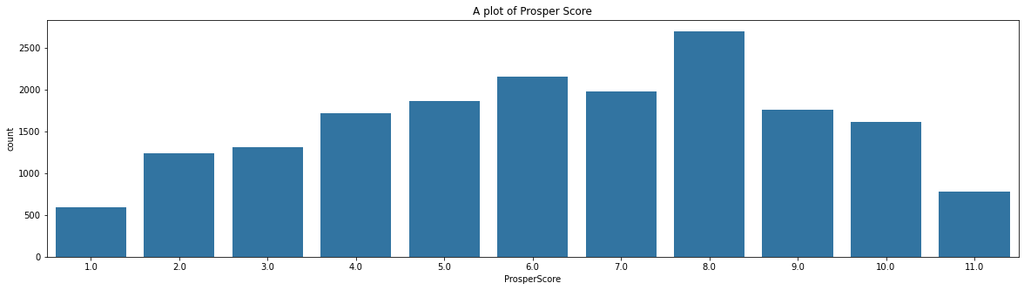

```python
plt.figure(figsize=[20,5])
sb.countplot (data = prosperLoan , x = "ProsperScore", color=fav_color )
plt.title('A plot of Prosper Score');
```

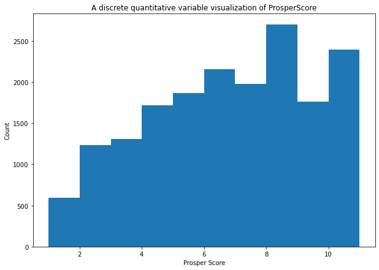

```python
# A discrete quantitative variable visualization of ProsperScore
plt.rcParams["figure.figsize"] = (10,7)
plt.hist(data = prosperLoan, x = "ProsperScore")
plt.title('A discrete quantitative variable visualization of ProsperScore')
plt.xlabel('Prosper Score')
plt.ylabel('Count');
```

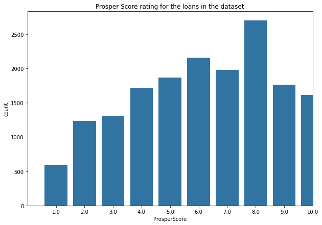

```python
color_fav = sb.color_palette()[0]
sb.countplot(data = prosperLoan , x = "ProsperScore",color= color_fav)
plt.xlim([-1,9])
plt.title('Prosper Score rating for the loans in the dataset');
```

#### Since we have looked at numerical univariate data we can look at some few Categorical univariate data

> Categorical univariate data consists of non numerical observation that may be placed as categories

#### for example, the categorical data here are EmploymentStatus, Occupation, IncomeRange,Loanstatus

## The main monetary ranges of existing clients

```python
# This is a Ordinal categorical data since there is a ranking or ordering of income range
income_count = prosperLoan["IncomeRange"].value_counts()
```

```python
income_count
```

```
$50,000-74,999    5403
$25,000-49,999    4977
$100,000+         3356
$75,000-99,999    3153
$1-24,999          808
Not employed         1
Name: IncomeRange, dtype: int64
```

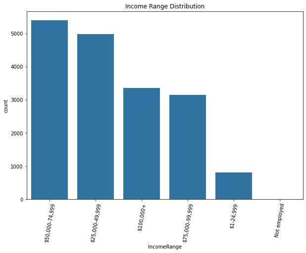

```python
income_order=income_count.index
color_fav= sb.color_palette()[0]
sb.countplot(data = prosperLoan, x = "IncomeRange", color= color_fav, order=income_order)
plt.xticks(rotation = 80)
plt.title('Income Range Distribution');
```

## Distribution of Loan Status

#### Lets check for categorical variable for loanstatus, to know the count of loan status in the distribution .ie lets know the no of loan that has been defaulted, or past due data and so on

```python
prosperLoan["LoanStatus"].value_counts()
```

```
Current                   9784
Completed                 5839
Chargedoff                1226
Defaulted                  263
Past Due (1-15 days)       223
Past Due (91-120 days)      83
Past Due (61-90 days)       81
Past Due (31-60 days)       77
Past Due (16-30 days)       65
FinalPaymentInProgress      52
Past Due (>120 days)         5
Name: LoanStatus, dtype: int64
```

```python
loan_status  = prosperLoan["LoanStatus"].value_counts()
loan_status
```

```
Current                   9784
Completed                 5839
Chargedoff                1226
Defaulted                  263
Past Due (1-15 days)       223
Past Due (91-120 days)      83
Past Due (61-90 days)       81
Past Due (31-60 days)       77
Past Due (16-30 days)       65
FinalPaymentInProgress      52
Past Due (>120 days)         5
Name: LoanStatus, dtype: int64
```

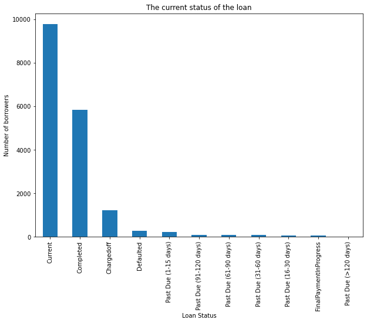

```python
plt.rcParams["figure.figsize"] = (10,7)
loan_status.plot(kind='bar')
plt.title('The current status of the loan')
plt.xlabel('Loan Status')
plt.ylabel('Number of borrowers');
```

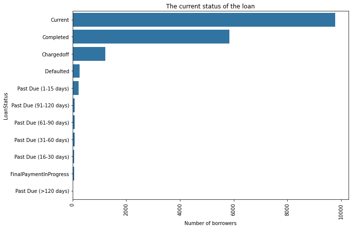

```python
order_LoanStatusIndex = prosperLoan["LoanStatus"].value_counts().index
sb.countplot(data = prosperLoan , y = "LoanStatus", order=order_LoanStatusIndex, color= color_fav)
plt.xticks(rotation = 90)
plt.title('The current status of the loan')
plt.xlabel('Number of borrowers');
```

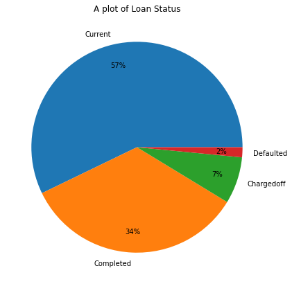

```python
# Getting a small representation on a pie chart for the major loan status ie Current, Completed, ChargeOff, Defaulted
loan_status_major  = prosperLoan["LoanStatus"].value_counts()[:4]
label_loan = loan_status_major.index
plt.pie(loan_status_major, labels= label_loan , pctdistance= 0.8 , autopct = "%.f%%")
plt.title('A plot of Loan Status');
```

> About 57% of the information is made up primarily of Current loans. Another significant component of the listings, at 34%, is made up of Completed loans. Even though there aren't many loans that default, roughly 7% of them are charged off, suggesting losses for investors. It will be difficult to determine at this time if borrowers have been making their loan payments because the majority of the listings are current loans.

### The data below comprises of nominal data , since there is no ranking of any sort

## Employment status Distribution

```python
# Norminal data as observed in employment status
employmentStatus = prosperLoan["EmploymentStatus"].value_counts()
employmentStatus
```

```
Employed         12656
Full-time         4314
Other              431
Retired            192
Part-time           99
Self-employed        5
Not employed         1
Name: EmploymentStatus, dtype: int64
```

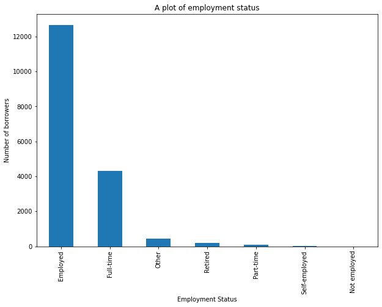

```python
# A plot of employment status
plt.rcParams["figure.figsize"] = (10,7)
employmentStatus.plot(kind='bar')
plt.title('A plot of employment status')
plt.xlabel('Employment Status')
plt.ylabel('Number of borrowers');
```

## Is a borrower a home owner or not

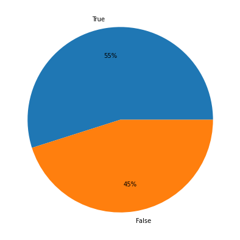

```python
### We can check to see if borrower is house owner
house_owner = prosperLoan["IsBorrowerHomeowner"].value_counts()
house_ownerLabeled = house_owner.index
plt.pie(house_owner, labels= house_ownerLabeled , pctdistance= 0.7 , autopct = "%.f%%");
```

## Occupational characteristics of Borrowers

```python
# Norminal data as observed in occupation
occupation = prosperLoan["Occupation"].value_counts()
occupation
```

```
Other                          4168
Professional                   2794
Computer Programmer             919
Executive                       779
Analyst                         721
                               ...
Judge                             4
Student - College Freshman        3
Homemaker                         3
Student - Community College       2
Student - College Sophomore       1
Name: Occupation, Length: 66, dtype: int64
```

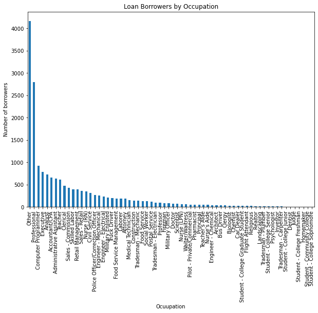

```python
# A bar chart for showing occupation
occupation.plot(kind='bar')
plt.title('Loan Borrowers by Occupation')
plt.xlabel('Ocuupation')
plt.ylabel('Number of borrowers');
```

### Checking which occupation has the largest number of borrowers

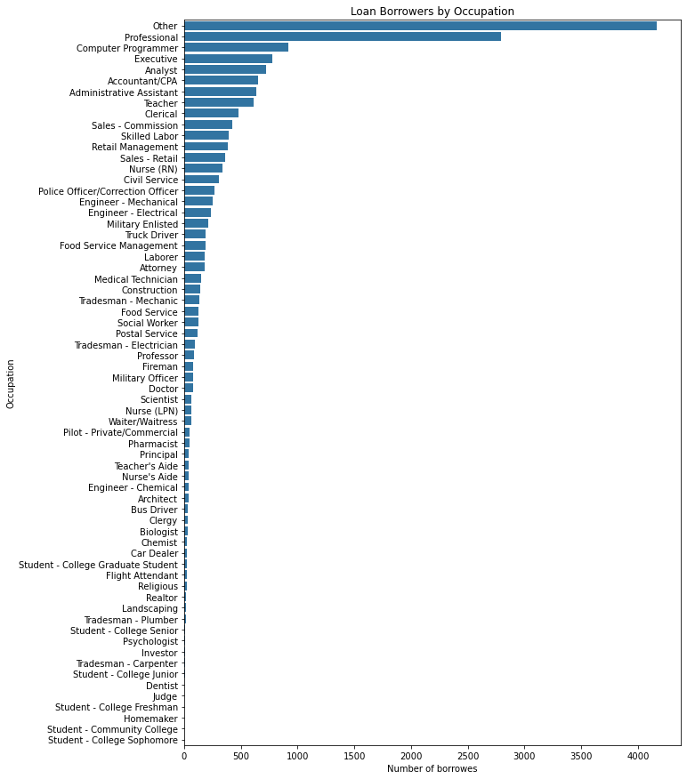

```python
order_OccupationIndex = prosperLoan["Occupation"].value_counts().index
plt.figure(figsize=[10,15])
sb.countplot(data = prosperLoan,y = "Occupation" , order = order_OccupationIndex,color= color_fav)
plt.title('Loan Borrowers by Occupation')
plt.xlabel('Number of borrowes');
```

# Bivarate Analysis ~ Analysis that involves looking out for relationship that exist between two variables

> The variables can be qualitative and quantitative, or qualitative and Quantitative , or qualitative and qualitative , we shall explore them here by ploting each for all the categorical

```python
prosperLoan.sample(4)
```

|  | LoanStatus | LenderYield | ProsperRating | ProsperScore | BorrowerAPR | BorrowerRate | ListingCategory | DebtToIncomeRatio | EstimatedEffectiveYield | Occupation | ... | IsBorrowerHomeowner | CurrentDelinquencies | AmountDelinquent | DelinquenciesLast7Years | IncomeRange | TotalProsperLoans | LoanOriginalAmount | OnTimeProsperPayments | BorrowerState | Investors |
| --- | --- | --- | --- | --- | --- | --- | --- | --- | --- | --- | --- | --- | --- | --- | --- | --- | --- | --- | --- | --- | --- |
| 8398 | Current | 0.1059 | 6.0 | 8.0 | 0.14409 | 0.1159 | Debt Consolidation | 0.29 | 0.10208 | Clerical | ... | False | 0.0 | 0.0 | 0.0 | $25,000-49,999 | 1.0 | 10000 | 9.0 | VA | 1 |
| 103050 | Current | 0.1250 | 5.0 | 10.0 | 0.17138 | 0.1350 | Vacation | 0.28 | 0.11858 | Clerical | ... | False | 0.0 | 0.0 | 0.0 | $25,000-49,999 | 1.0 | 2000 | 1.0 | HI | 8 |
| 108451 | Current | 0.1634 | 4.0 | 5.0 | 0.21025 | 0.1734 | Home Improvement | 0.15 | 0.15970 | Teacher | ... | True | 2.0 | 0.0 | 12.0 | $75,000-99,999 | 1.0 | 15000 | 5.0 | VA | 19 |
| 79229 | Current | 0.0749 | 7.0 | 10.0 | 0.09837 | 0.0849 | Debt Consolidation | 0.20 | 0.07310 | Other | ... | False | 0.0 | 0.0 | 0.0 | $25,000-49,999 | 3.0 | 2350 | 89.0 | IL | 45 |

4 rows × 21 columns

#### We want to check if the change in proper score have any effect on TotalProsperLoans, here we can use scatter chart since the two variables are quantitative

```python
# Checking for correlation between two values
prosperLoan.corr()["TotalProsperLoans"].sort_values(ascending = False)
```

```
TotalProsperLoans          1.000000
OnTimeProsperPayments      0.708272
ProsperScore               0.067569
LoanOriginalAmount         0.047103
ProsperRating              0.043421
IsBorrowerHomeowner        0.014542
DebtToIncomeRatio          0.008363
AmountDelinquent           0.001869
CurrentDelinquencies       0.000527
EstimatedEffectiveYield   -0.006584
Investors                 -0.019197
DelinquenciesLast7Years   -0.027089
LenderYield               -0.048388
BorrowerRate              -0.048419
BorrowerAPR               -0.048572
Name: TotalProsperLoans, dtype: float64
```

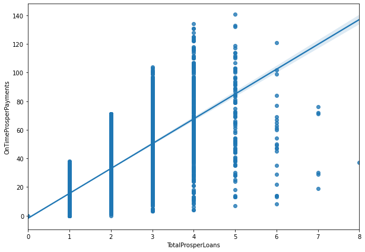

```python
sb.regplot(data = prosperLoan , x = "TotalProsperLoans", y = "OnTimeProsperPayments" );
```

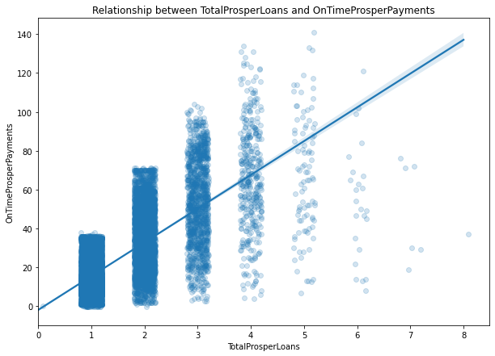

```python
sb.regplot(data = prosperLoan , x = "TotalProsperLoans", y = "OnTimeProsperPayments", fit_reg = True,
           x_jitter = 0.2, y_jitter = 0.2, scatter_kws = {'alpha' : 1/5})
plt.title('Relationship between TotalProsperLoans and OnTimeProsperPayments');
```

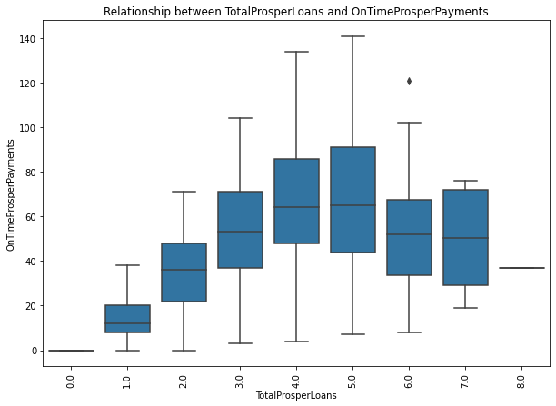

```python
color_favorite = sb.color_palette()[0]
sb.boxplot(data = prosperLoan , x = "TotalProsperLoans", y = "OnTimeProsperPayments",color=color_favorite)
plt.xticks(rotation = 90)
plt.title('Relationship between TotalProsperLoans and OnTimeProsperPayments');
```

We can observe, that there is a correlation that exist between TotalProsperLoans and onTimeProsperPayments

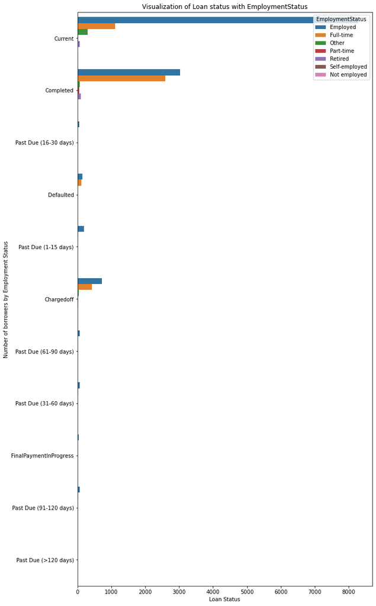

```python
plt.figure(figsize=[10,20])
sb.countplot(data = prosperLoan, y = "LoanStatus", hue = "EmploymentStatus")
plt.title('Visualization of Loan status with EmploymentStatus')
plt.xlabel('Loan Status')
plt.ylabel('Number of borrowers by Employment Status');
```

> It can be observed that current Loan status has majority of borrowes where the employeed group in Employee Status has the majority of borrowers

## What is the average properscore per employmentStatus?

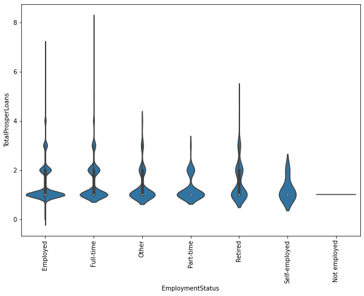

```python
color_favorite = sb.color_palette()[0]
sb.violinplot(data = prosperLoan , x = "EmploymentStatus", y = "TotalProsperLoans",color=color_favorite)
plt.xticks(rotation = 90);
```

```python
prosperLoan.groupby("EmploymentStatus")["TotalProsperLoans"].mean().sort_values(ascending = False)
```

```
EmploymentStatus
Full-time        1.526657
Retired          1.526042
Employed         1.441767
Other            1.354988
Part-time        1.252525
Self-employed    1.200000
Not employed     1.000000
Name: TotalProsperLoans, dtype: float64
```

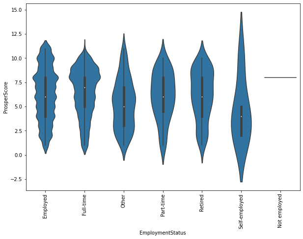

```python
color_favorite = sb.color_palette()[0]
sb.violinplot(data = prosperLoan , x = "EmploymentStatus", y = "ProsperScore",color=color_favorite)
plt.xticks(rotation = 90);
```

> The rate of borrowing across the employee Status seems to be average across all the groups, with those in Full-time group having most borrowers with a prosperScore of above the median

### What is the relationship of OnTimeProsperPayments with TotalProsperLoans?

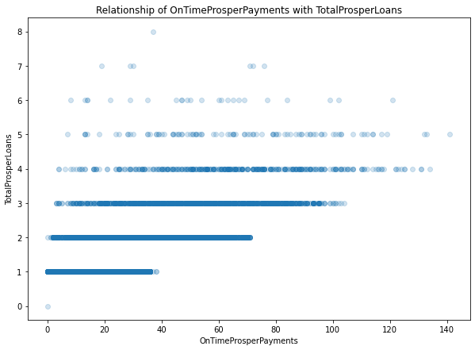

```python
plt.scatter(data = prosperLoan , x = "OnTimeProsperPayments", y = "TotalProsperLoans", alpha=0.2)
plt.title('Relationship of OnTimeProsperPayments with TotalProsperLoans')
plt.xlabel('OnTimeProsperPayments')
plt.ylabel('TotalProsperLoans');
```

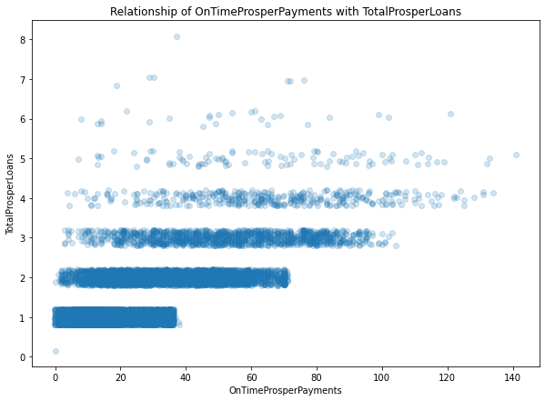

```python
sb.regplot(data = prosperLoan , x = "OnTimeProsperPayments", y = "TotalProsperLoans", fit_reg = False,
           x_jitter = 0.2, y_jitter = 0.2, scatter_kws = {'alpha' : 1/5})
plt.title('Relationship of OnTimeProsperPayments with TotalProsperLoans');
```

> A strong relationship can be observed between Totalprosperloans and onTimeProsperpayments

### What is the relationship of LenderYield with ProsperRating?

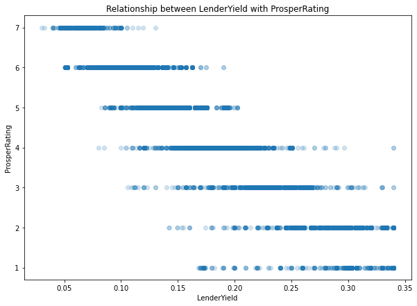

```python
plt.scatter(data = prosperLoan , x ="LenderYield" , y = "ProsperRating",alpha=0.2)
plt.title('Relationship between LenderYield with ProsperRating')
plt.xlabel('LenderYield')
plt.ylabel('ProsperRating');
```

> There is a negative correlation between lender yield and Prosper rating , when we have a reduced prosper score , then this will lead to an increase lender yield

## Which occupation gets highest loan amount on an average?

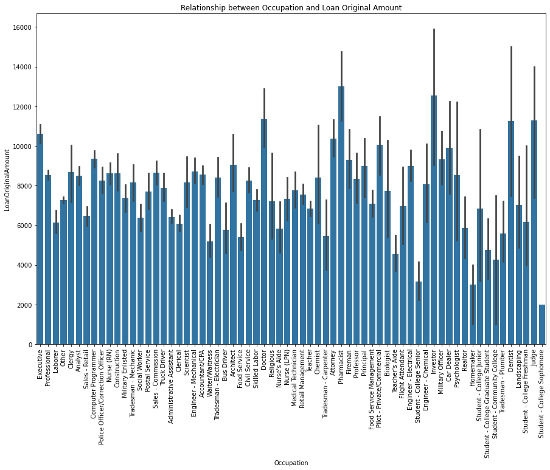

```python
plt.figure(figsize=[15,10])
color_fav = sb.color_palette()[0]
sb.barplot(data = prosperLoan , x = "Occupation" , y = "LoanOriginalAmount", color = color_fav)
plt.xticks(rotation = 90)
plt.title('Relationship between Occupation and Loan Original Amount');
```

## How does loan amount differ with respect to the income range?

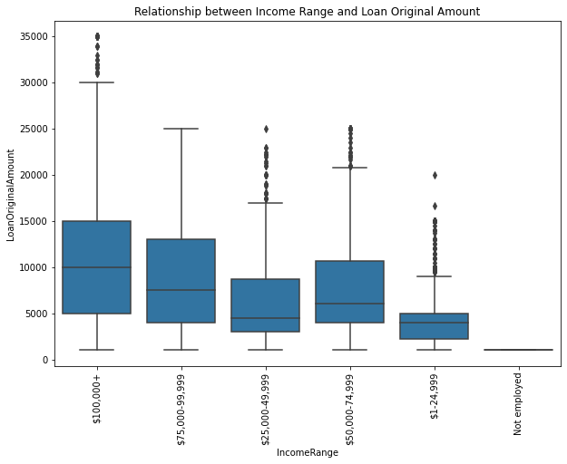

```python
color_fav = sb.color_palette()[0]
sb.boxplot(data = prosperLoan , x = "IncomeRange" , y = "LoanOriginalAmount",color = color_fav)
plt.xticks(rotation = 90)
plt.title('Relationship between Income Range and Loan Original Amount');
```

```python
prosperLoan.info()
```

```
<class 'pandas.core.frame.DataFrame'>
Int64Index: 17698 entries, 4 to 113935
Data columns (total 21 columns):
 #   Column                   Non-Null Count  Dtype
---  ------                   --------------  -----
 0   LoanStatus               17698 non-null  object
 1   LenderYield              17698 non-null  float64
 2   ProsperRating            17698 non-null  float64
 3   ProsperScore             17698 non-null  float64
 4   BorrowerAPR              17698 non-null  float64
 5   BorrowerRate             17698 non-null  float64
 6   ListingCategory          17698 non-null  object
 7   DebtToIncomeRatio        17698 non-null  float64
 8   EstimatedEffectiveYield  17698 non-null  float64
 9   Occupation               17698 non-null  object
 10  EmploymentStatus         17698 non-null  object
 11  IsBorrowerHomeowner      17698 non-null  bool
 12  CurrentDelinquencies     17698 non-null  float64
 13  AmountDelinquent         17698 non-null  float64
 14  DelinquenciesLast7Years  17698 non-null  float64
 15  IncomeRange              17698 non-null  object
 16  TotalProsperLoans        17698 non-null  float64
 17  LoanOriginalAmount       17698 non-null  int64
 18  OnTimeProsperPayments    17698 non-null  float64
 19  BorrowerState            17698 non-null  object
 20  Investors                17698 non-null  int64
dtypes: bool(1), float64(12), int64(2), object(6)
memory usage: 3.4+ MB
```

## Multivariate Exploration

> Creating plots of three or more variables to investigate the data even further.

#### A heatmap highlighting correlation between the values

```python
prosperLoan_corr = prosperLoan.corr()
```

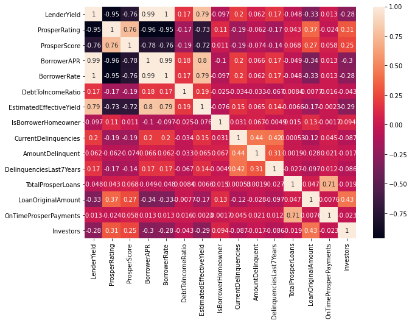

```python
sb.heatmap(prosperLoan_corr, annot=True );
```

```python
def multivariate_facetGrid():
    g = sb.FacetGrid(data = prosperLoan , col= "LoanStatus" , col_wrap= 4 )
    g.map(sb.regplot, "LenderYield", "ProsperRating")
    g.set_titles("{col_name}");
```

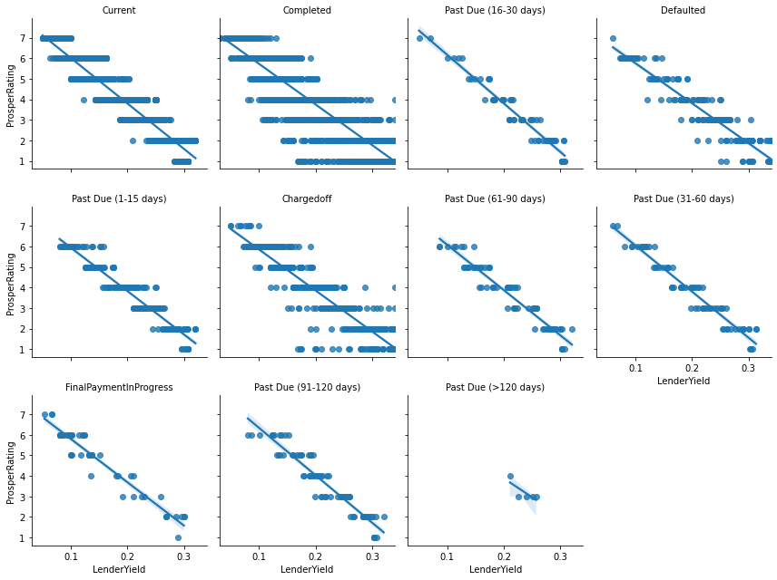

```python
multivariate_facetGrid()
```

```python
def multivariate_facetPlot():
    g = sb.FacetGrid(data = prosperLoan , col= "LoanStatus" , col_wrap= 4 )
    g.map(sb.regplot, "LenderYield", "ProsperRating")
    g.set_titles("{col_name}");
```

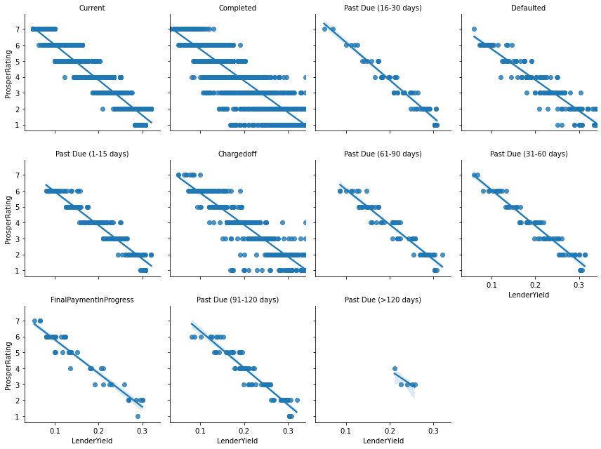

```python
multivariate_facetPlot()
```

# Conclusions

> From our analysis it can be observed that majority of borrowers seek loans to pay off their current debt or consolidate new debt. This proportion is significantly higher than individuals who apply for loans for common causes including home remodeling, business, car-related expenses, and medical needs. The most money is typically borrowed for **debt consolidation**.

> We can see that the status of most loans are current with a percentage of 57%. A positive repayment trend is observed, having most loan status completed at a percentage of 34% compared to those that have been defaulted at a percentage of 2%.